# Homework 2

Natalie Sawtelle

2025-09-17

# Problem 1: Speed Reduction

- What are the **Experimental Units** in this study?
  - **15 different Drivers**
- What is the **response variable** in this study?
  - **Change in Average Acceleration**
- What is the **factor** in this study?
  - **Speed Reduction Markings**
- How many **factor levels** are there?
  - **1 = “None”, 2 = “Longitudinal, 3 =”Traverse”**
- What are the **treatments**?
  - **Each of the 15 drivers paired with each factor level**
- What are the **controlled factors**?
  - **Vehicle and Road**

```r
cars <- read_csv("carspeed.csv", show_col_types=FALSE)
```

```r
cars <- cars |>
  rename(
    Treatment = Trt,
    Accelerate = accelerate) |>
  mutate(Treatment_fct = factor(Treatment,
                                    labels=c("None", "Longitudinal", "Traverse"))) |>
  select(Treatment_fct, Subject, Accelerate)
glimpse(cars)
```

```
## Rows: 45
## Columns: 3
## $ Treatment_fct <fct> None, Longitudinal, Traverse, None, Longitudinal, Traver…
## $ Subject       <dbl> 1, 1, 1, 2, 2, 2, 3, 3, 3, 4, 4, 4, 5, 5, 5, 6, 6, 6, 7,…
## $ Accelerate    <dbl> 0.53, 0.49, 0.24, 0.07, 0.05, -0.15, 0.02, -0.37, -0.26,…
```

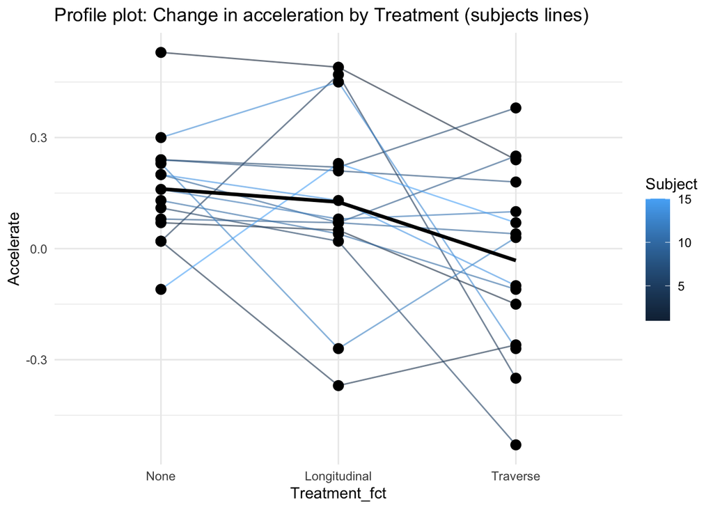

```r
p_list <- list()
profile_plot <- ggplot(cars, aes(x=Treatment_fct, y=Accelerate, group=Subject)) +
  geom_line(aes(color=Subject), alpha=0.6) +
  stat_summary(fun=mean, geom="line", aes(group=1), size=1.2) +
  stat_summary(fun=mean, geom="point", size=3) +
  ggtitle("Profile plot: Change in acceleration by Treatment (subjects lines)") +
  theme_minimal()
print(profile_plot)
```

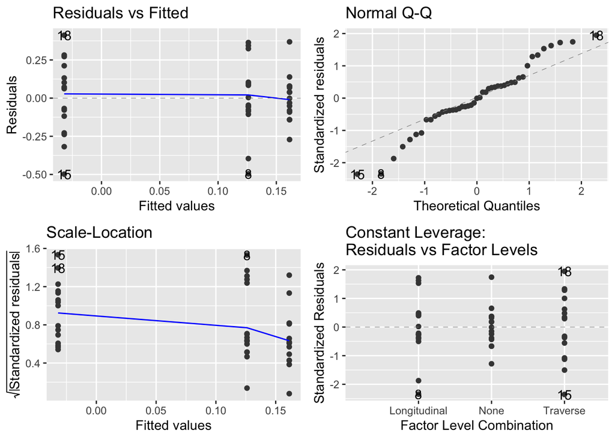

```r
anova_model1 <- aov(Accelerate ~ Treatment_fct, data = cars)
autoplot(anova_model1)
```

**Nothing too concerning appears in these plots. The Normal QQ has a few outliers, but they mostly follow the diagonal line.**

```r
summary(anova_model1)
```

```
##               Df Sum Sq Mean Sq F value Pr(>F)
## Treatment_fct  2  0.318 0.15898   3.317  0.046 *
## Residuals     42  2.013 0.04793
## ---
## Signif. codes:  0 '***' 0.001 '**' 0.01 '*' 0.05 '.' 0.1 ' ' 1
```

# Problem 2: Lacrosse Helmets

```r
lacrosse <- read_table("lacrosse_helmet.txt", col_names = TRUE)
lacrosse <- lacrosse |>
  mutate(Model = factor(Model,
                                    labels=c("SCH", "SHCAF", "SHCUL", "BUL")),
         Side = factor(Side,
                                    labels=c("Front", "Back"))) |>
  select(Model, Side, GADD)
glimpse(lacrosse)
```

```
## Rows: 80
## Columns: 3
## $ Model <fct> SCH, SCH, SCH, SCH, SCH, SCH, SCH, SCH, SCH, SCH, SCH, SCH, SCH,…
## $ Side  <fct> Front, Front, Front, Front, Front, Front, Front, Front, Front, F…
## $ GADD  <dbl> 1033.120, 1348.208, 1071.822, 976.702, 990.100, 1099.040, 1199.1…
```

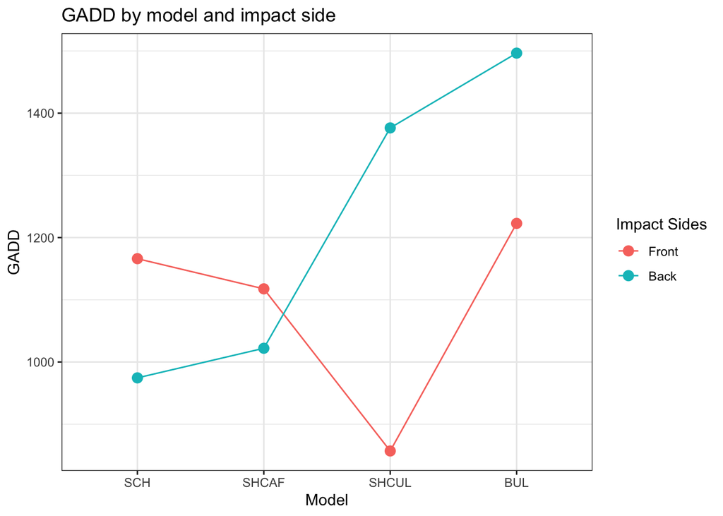

```r
ggplot(lacrosse, aes(x=Model, y=GADD, col=factor(Side), group=Side) )+
  stat_summary(fun="mean", geom="point", size=3) +
  stat_summary(fun="mean", geom="line") +
  theme_bw() +
  labs(color="Impact Sides",
       x="Model",
       y="GADD",
       title="GADD by model and impact side")
```

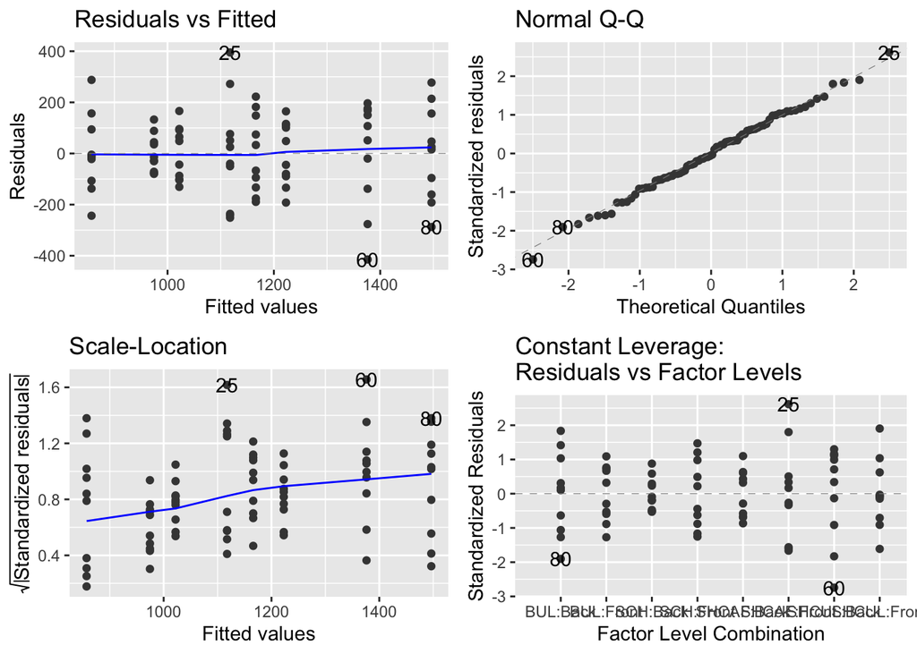

```r
anova_model2 <- aov(GADD ~ Model * Side, data = lacrosse)
autoplot(anova_model2)
```

**It appears there is no concern in the Residuals vs Fitted and Scale-Location plots and overall Normality appears satisfied based on the Q-Q plot.**

```r
summary(anova_model2)
```

```
##             Df  Sum Sq Mean Sq F value   Pr(>F)
## Model        3 1155478  385159   15.18 9.46e-08 ***
## Side         1  319918  319918   12.61 0.000682 ***
## Model:Side   3 1632156  544052   21.44 4.99e-10 ***
## Residuals   72 1826954   25374
## ---
## Signif. codes:  0 '***' 0.001 '**' 0.01 '*' 0.05 '.' 0.1 ' ' 1
```

**There is significant relationship between model, side, and the model and side combined with the GADD score.**

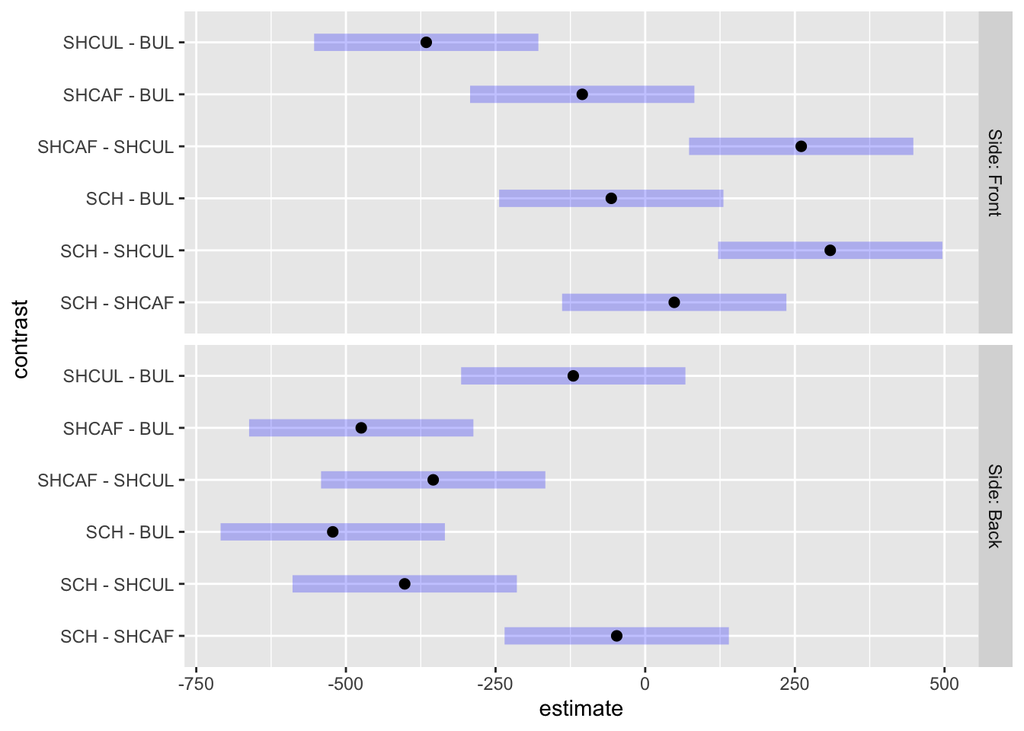

```r
lacrosse_mc <- emmeans(anova_model2, ~ Model | Side)
plot(contrast(lacrosse_mc, "tukey"))
```

**We see a more negative leaning estimate when the side is the back, while when it is the front, the estimate leans more positive.**

# Problem 3: Caffeine and Endurance

- What are the **Experimental Units** in this study?
  - **9 different Cyclists**
- What is the **response variable** in this study?
  - **Endurance time**
- What is the **factor** in this study?
  - **caffeine dosage**
- How many **factor levels** are there?
  - **4 dosage levels**
- What are the **controlled factors**?
  - **The researcher made sure no cyclist was ever tested on consecutive days**

```r
cycle <- read_csv("cyclist_caffeine.csv", show_col_types = FALSE)
```

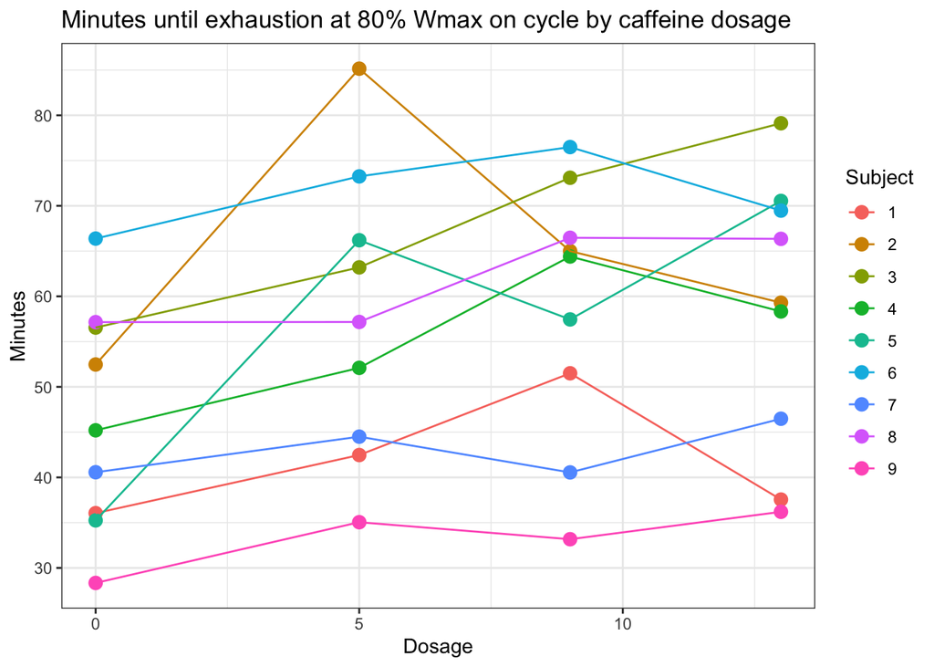

```r
ggplot(cycle, aes(x=dose_c, y=endtime, col=factor(subject_c), group=subject_c) )+
  stat_summary(fun="mean", geom="point", size=3) +
  stat_summary(fun="mean", geom="line") +
  theme_bw() +
  labs(color="Subject",
       x="Dosage",
       y="Minutes",
       title="Minutes until exhaustion at 80% Wmax on cycle by caffeine dosage")
```

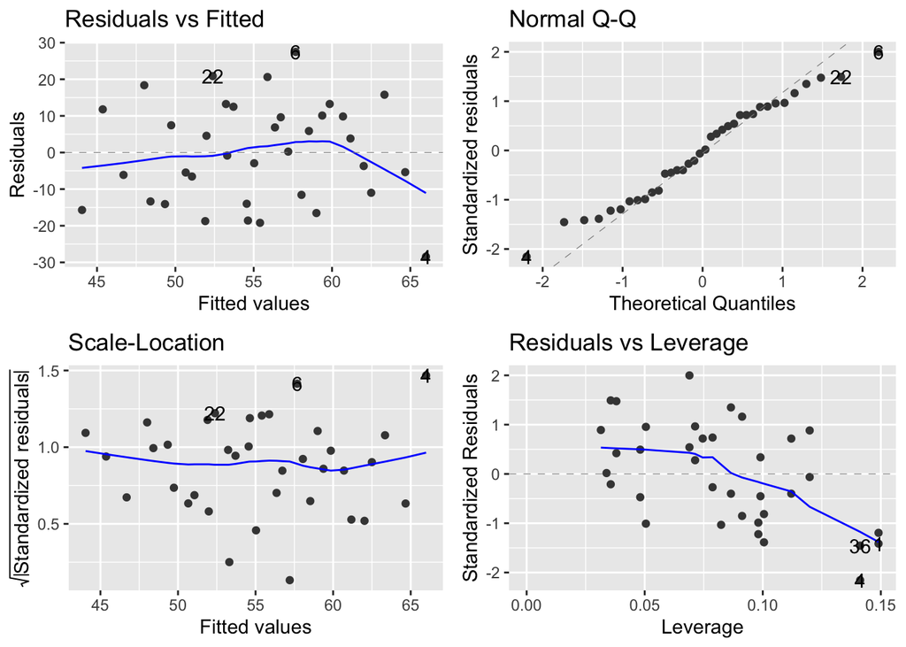

```r
anova_model3 <- aov(endtime ~ dose_c + subject_c, data = cycle)
autoplot(anova_model3)
```

**The residuals vs. fitted suggest possible violations of linear regression assumptions, while normality appears satisfied based on the Q-Q plot.**

```r
summary(anova_model3)
```

```
##             Df Sum Sq Mean Sq F value Pr(>F)
## dose_c       1    638   637.6   3.143 0.0855 .
## subject_c    1    421   420.7   2.074 0.1593
## Residuals   33   6694   202.9
## ---
## Signif. codes:  0 '***' 0.001 '**' 0.01 '*' 0.05 '.' 0.1 ' ' 1
```

**Neither dosage nor subject treatments show a significant affect on the minutes to exhustion, therefore we do not need to make a multiple comparisons graph.**